# 13. 작업 1유형 -2

```python
import pandas as pd


channel =pd.read_csv('https://raw.githubusercontent.com/Datamanim/datarepo/main/youtube/channelInfo.csv')
video =pd.read_csv('https://raw.githubusercontent.com/Datamanim/datarepo/main/youtube/videoInfo.csv')
channel
```

|  | channelid | subcnt | viewcnt | videocnt | ct | channelname |
| --- | --- | --- | --- | --- | --- | --- |
| 0 | UCkQCwnkQfgSuPTTnw_Y7v7w | 1310000 | 410238653 | 736 | 2021-09-30 03:01:03 | 꽈뚜룹 |
| 1 | UCkQCwnkQfgSuPTTnw_Y7v7w | 1310000 | 412531322 | 736 | 2021-09-30 09:01:03 | 꽈뚜룹 |
| 2 | UCkQCwnkQfgSuPTTnw_Y7v7w | 1310000 | 412531322 | 735 | 2021-09-30 15:01:03 | 꽈뚜룹 |
| 3 | UCkQCwnkQfgSuPTTnw_Y7v7w | 1310000 | 412531322 | 737 | 2021-09-30 21:01:03 | 꽈뚜룹 |
| 4 | UCkQCwnkQfgSuPTTnw_Y7v7w | 1320000 | 412531322 | 737 | 2021-10-01 03:01:04 | 꽈뚜룹 |
| ... | ... | ... | ... | ... | ... | ... |
| 1390 | UCbBzKnCYcG7E3EIkSTdsawA | 56700 | 7528614 | 57 | 2021-10-31 15:01:04 | Balming Tiger |
| 1391 | UCbBzKnCYcG7E3EIkSTdsawA | 56700 | 7528614 | 57 | 2021-10-31 21:01:04 | Balming Tiger |
| 1392 | UCbBzKnCYcG7E3EIkSTdsawA | 56800 | 7528614 | 57 | 2021-11-01 03:01:03 | Balming Tiger |
| 1393 | UCbBzKnCYcG7E3EIkSTdsawA | 56800 | 7539876 | 57 | 2021-11-01 09:01:04 | Balming Tiger |
| 1394 | UCbBzKnCYcG7E3EIkSTdsawA | 56800 | 7539876 | 57 | 2021-11-01 15:01:07 | Balming Tiger |

1395 rows × 6 columns

```python
video
```

|  | videopk | viewcnt | likecnt | dislikecnt | favoritecnt | cmcnt | ct | videoname |
| --- | --- | --- | --- | --- | --- | --- | --- | --- |
| 0 | c5JQp6xafqc | 1667010 | 30474 | 706 | 0 | 6587 | 2021-10-10 15:20:03 | 공범 EP1 |
| 1 | c5JQp6xafqc | 1669089 | 30495 | 707 | 0 | 6589 | 2021-10-10 15:30:03 | 공범 EP1 |
| 2 | c5JQp6xafqc | 1674759 | 30522 | 711 | 0 | 6596 | 2021-10-10 15:40:02 | 공범 EP1 |
| 3 | c5JQp6xafqc | 1677026 | 30555 | 712 | 0 | 6604 | 2021-10-10 15:50:03 | 공범 EP1 |
| 4 | c5JQp6xafqc | 1681824 | 30585 | 713 | 0 | 6600 | 2021-10-10 16:00:03 | 공범 EP1 |
| ... | ... | ... | ... | ... | ... | ... | ... | ... |
| 15196 | yZt-h-KcmUE | 1285474 | 25582 | 3615 | 0 | 31603 | 2021-11-01 14:50:06 | 공범 EP8 |
| 15197 | yZt-h-KcmUE | 1286376 | 25592 | 3617 | 0 | 31627 | 2021-11-01 15:00:05 | 공범 EP8 |
| 15198 | yZt-h-KcmUE | 1287172 | 25597 | 3619 | 0 | 31643 | 2021-11-01 15:10:05 | 공범 EP8 |
| 15199 | yZt-h-KcmUE | 1288138 | 25606 | 3619 | 0 | 31648 | 2021-11-01 15:20:04 | 공범 EP8 |
| 15200 | yZt-h-KcmUE | 1289088 | 25616 | 3621 | 0 | 31663 | 2021-11-01 15:30:05 | 공범 EP8 |

15201 rows × 8 columns

## 1. 각 데이터의 ct 칼럼을 datetime으로 바꾸고, video의 videoname의 각 value 마다 몇개의 데이터씩 가지고 있는지 확인

```python
channel['ct'] = pd.to_datetime(channel['ct'])
video['ct'] = pd.to_datetime(video['ct'])

channel
```

|  | channelid | subcnt | viewcnt | videocnt | ct | channelname |
| --- | --- | --- | --- | --- | --- | --- |
| 0 | UCkQCwnkQfgSuPTTnw_Y7v7w | 1310000 | 410238653 | 736 | 2021-09-30 03:01:03 | 꽈뚜룹 |
| 1 | UCkQCwnkQfgSuPTTnw_Y7v7w | 1310000 | 412531322 | 736 | 2021-09-30 09:01:03 | 꽈뚜룹 |
| 2 | UCkQCwnkQfgSuPTTnw_Y7v7w | 1310000 | 412531322 | 735 | 2021-09-30 15:01:03 | 꽈뚜룹 |
| 3 | UCkQCwnkQfgSuPTTnw_Y7v7w | 1310000 | 412531322 | 737 | 2021-09-30 21:01:03 | 꽈뚜룹 |
| 4 | UCkQCwnkQfgSuPTTnw_Y7v7w | 1320000 | 412531322 | 737 | 2021-10-01 03:01:04 | 꽈뚜룹 |
| ... | ... | ... | ... | ... | ... | ... |
| 1390 | UCbBzKnCYcG7E3EIkSTdsawA | 56700 | 7528614 | 57 | 2021-10-31 15:01:04 | Balming Tiger |
| 1391 | UCbBzKnCYcG7E3EIkSTdsawA | 56700 | 7528614 | 57 | 2021-10-31 21:01:04 | Balming Tiger |
| 1392 | UCbBzKnCYcG7E3EIkSTdsawA | 56800 | 7528614 | 57 | 2021-11-01 03:01:03 | Balming Tiger |
| 1393 | UCbBzKnCYcG7E3EIkSTdsawA | 56800 | 7539876 | 57 | 2021-11-01 09:01:04 | Balming Tiger |
| 1394 | UCbBzKnCYcG7E3EIkSTdsawA | 56800 | 7539876 | 57 | 2021-11-01 15:01:07 | Balming Tiger |

1395 rows × 6 columns

```python
video
```

|  | videopk | viewcnt | likecnt | dislikecnt | favoritecnt | cmcnt | ct | videoname |
| --- | --- | --- | --- | --- | --- | --- | --- | --- |
| 0 | c5JQp6xafqc | 1667010 | 30474 | 706 | 0 | 6587 | 2021-10-10 15:20:03 | 공범 EP1 |
| 1 | c5JQp6xafqc | 1669089 | 30495 | 707 | 0 | 6589 | 2021-10-10 15:30:03 | 공범 EP1 |
| 2 | c5JQp6xafqc | 1674759 | 30522 | 711 | 0 | 6596 | 2021-10-10 15:40:02 | 공범 EP1 |
| 3 | c5JQp6xafqc | 1677026 | 30555 | 712 | 0 | 6604 | 2021-10-10 15:50:03 | 공범 EP1 |
| 4 | c5JQp6xafqc | 1681824 | 30585 | 713 | 0 | 6600 | 2021-10-10 16:00:03 | 공범 EP1 |
| ... | ... | ... | ... | ... | ... | ... | ... | ... |
| 15196 | yZt-h-KcmUE | 1285474 | 25582 | 3615 | 0 | 31603 | 2021-11-01 14:50:06 | 공범 EP8 |
| 15197 | yZt-h-KcmUE | 1286376 | 25592 | 3617 | 0 | 31627 | 2021-11-01 15:00:05 | 공범 EP8 |
| 15198 | yZt-h-KcmUE | 1287172 | 25597 | 3619 | 0 | 31643 | 2021-11-01 15:10:05 | 공범 EP8 |
| 15199 | yZt-h-KcmUE | 1288138 | 25606 | 3619 | 0 | 31648 | 2021-11-01 15:20:04 | 공범 EP8 |
| 15200 | yZt-h-KcmUE | 1289088 | 25616 | 3621 | 0 | 31663 | 2021-11-01 15:30:05 | 공범 EP8 |

15201 rows × 8 columns

```python
video['videoname'].value_counts()
```

```
videoname
 공범 EP1    3492
 공범 EP2    3204
 공범 EP3    2568
 공범 EP4    2280
 공범 EP5    1562
 공범 EP6    1274
 공범 EP7     555
 공범 EP8     266
Name: count, dtype: int64
```

## 2. 각 video의 가장 최신화 된 날짜의 viewcount값을 출력

```python
video[['viewcnt','videoname','ct']].drop_duplicates(subset=['videoname'],keep='last')
```

|  | viewcnt | videoname | ct |
| --- | --- | --- | --- |
| 3491 | 3180532 | 공범 EP1 | 2021-11-01 15:30:03 |
| 6695 | 2199328 | 공범 EP2 | 2021-11-01 15:30:03 |
| 9263 | 1671294 | 공범 EP3 | 2021-11-01 15:30:03 |
| 11543 | 1818493 | 공범 EP4 | 2021-11-01 15:30:03 |
| 13105 | 1503435 | 공범 EP5 | 2021-11-01 15:30:04 |
| 13660 | 1630200 | 공범 EP7 | 2021-11-01 15:30:05 |
| 14934 | 1750222 | 공범 EP6 | 2021-11-01 15:30:04 |
| 15200 | 1289088 | 공범 EP8 | 2021-11-01 15:30:05 |

## 3. Channel 데이터중 2021-10-03일 이후 각 채널의 처음 기록 됐던 구독자 수(subcnt)를 출력

```python
channel[['subcnt','channelname']].loc[channel['ct']>pd.to_datetime('2021-10-03')].drop_duplicates(subset=['channelname'])
```

|  | subcnt | channelname |
| --- | --- | --- |
| 12 | 1330000 | 꽈뚜룹 |
| 139 | 257000 | 야전삽짱재 |
| 266 | 322000 | 츄정ChuJeong |
| 393 | 922000 | 논리왕 전기 |
| 520 | 55000 | 와글와글 WagleWagle |
| 647 | 215000 | 조나단 |
| 774 | 14900 | 형사!탐정되다 |
| 901 | 7520 | 김농밀의 농밀한 삶 |
| 1028 | 10100 | 릴펄 Lilpearl |
| 1155 | 471000 | 곽토리 kwak tori |
| 1276 | 54300 | Balming Tiger |

## 4. 각채널의 2021-10-03 03:00:00 ~ 2021-11-01 15:00:00 까지 구독자수 (subcnt) 의 증가량

```python
a = channel[['subcnt','channelname']].loc[channel['ct']<pd.to_datetime('2021-10-03 03')].drop_duplicates(keep='last',subset=['channelname'])
a = a.reset_index(drop=True)
a
```

|  | subcnt | channelname |
| --- | --- | --- |
| 0 | 1330000 | 꽈뚜룹 |
| 1 | 257000 | 야전삽짱재 |
| 2 | 322000 | 츄정ChuJeong |
| 3 | 922000 | 논리왕 전기 |
| 4 | 55000 | 와글와글 WagleWagle |
| 5 | 215000 | 조나단 |
| 6 | 14800 | 형사!탐정되다 |
| 7 | 7520 | 김농밀의 농밀한 삶 |
| 8 | 10100 | 릴펄 Lilpearl |
| 9 | 471000 | 곽토리 kwak tori |
| 10 | 54200 | Balming Tiger |

```python
b = channel[['subcnt','channelname']].loc[channel['ct']<pd.to_datetime('2021-11-01 15')].drop_duplicates(keep='last',subset=['channelname'])
b = b.reset_index(drop=True)
b
```

|  | subcnt | channelname |
| --- | --- | --- |
| 0 | 1400000 | 꽈뚜룹 |
| 1 | 268000 | 야전삽짱재 |
| 2 | 323000 | 츄정ChuJeong |
| 3 | 911000 | 논리왕 전기 |
| 4 | 55000 | 와글와글 WagleWagle |
| 5 | 227000 | 조나단 |
| 6 | 25200 | 형사!탐정되다 |
| 7 | 9060 | 김농밀의 농밀한 삶 |
| 8 | 21100 | 릴펄 Lilpearl |
| 9 | 469000 | 곽토리 kwak tori |
| 10 | 56800 | Balming Tiger |

```python
c = b
c['subcnt'] = b['subcnt'].subtract(a['subcnt'])
c
```

|  | subcnt | channelname |
| --- | --- | --- |
| 0 | 70000 | 꽈뚜룹 |
| 1 | 11000 | 야전삽짱재 |
| 2 | 1000 | 츄정ChuJeong |
| 3 | -11000 | 논리왕 전기 |
| 4 | 0 | 와글와글 WagleWagle |
| 5 | 12000 | 조나단 |
| 6 | 10400 | 형사!탐정되다 |
| 7 | 1540 | 김농밀의 농밀한 삶 |
| 8 | 11000 | 릴펄 Lilpearl |
| 9 | -2000 | 곽토리 kwak tori |
| 10 | 2600 | Balming Tiger |

## 5. 공범 EP1의 비디오정보 데이터중 수집간격이 5분 이하, 20분이상인 데이터 구간( 해당 시점 전,후) 의 시각을 모두 출력

```python
import datetime
```

```python
ep_one = video[video['videoname'].str.contains('1')].sort_values('ct').reset_index(drop=True)
ep_one
```

|  | videopk | viewcnt | likecnt | dislikecnt | favoritecnt | cmcnt | ct | videoname |
| --- | --- | --- | --- | --- | --- | --- | --- | --- |
| 0 | c5JQp6xafqc | 6396 | 680 | 3 | 0 | 226 | 2021-10-07 19:10:03 | 공범 EP1 |
| 1 | c5JQp6xafqc | 13087 | 1113 | 7 | 0 | 273 | 2021-10-07 19:20:02 | 공범 EP1 |
| 2 | c5JQp6xafqc | 19991 | 1446 | 12 | 0 | 363 | 2021-10-07 19:30:03 | 공범 EP1 |
| 3 | c5JQp6xafqc | 27451 | 1859 | 19 | 0 | 479 | 2021-10-07 19:40:03 | 공범 EP1 |
| 4 | c5JQp6xafqc | 36559 | 2306 | 23 | 0 | 602 | 2021-10-07 19:50:03 | 공범 EP1 |
| ... | ... | ... | ... | ... | ... | ... | ... | ... |
| 3487 | c5JQp6xafqc | 3179698 | 41040 | 1113 | 0 | 7673 | 2021-11-01 14:50:04 | 공범 EP1 |
| 3488 | c5JQp6xafqc | 3179971 | 41042 | 1113 | 0 | 7673 | 2021-11-01 15:00:03 | 공범 EP1 |
| 3489 | c5JQp6xafqc | 3179971 | 41042 | 1113 | 0 | 7673 | 2021-11-01 15:10:03 | 공범 EP1 |
| 3490 | c5JQp6xafqc | 3180332 | 41043 | 1113 | 0 | 7674 | 2021-11-01 15:20:02 | 공범 EP1 |
| 3491 | c5JQp6xafqc | 3180532 | 41043 | 1113 | 0 | 7674 | 2021-11-01 15:30:03 | 공범 EP1 |

3492 rows × 8 columns

```python
ep_one[
        (ep_one.ct.diff(1) >=datetime.timedelta(minutes=20)) | \
        (ep_one.ct.diff(1) <=datetime.timedelta(minutes=5))

      ]
```

|  | videopk | viewcnt | likecnt | dislikecnt | favoritecnt | cmcnt | ct | videoname |
| --- | --- | --- | --- | --- | --- | --- | --- | --- |
| 721 | c5JQp6xafqc | 2228250 | 34559 | 849 | 0 | 7191 | 2021-10-13 09:41:37 | 공범 EP1 |
| 722 | c5JQp6xafqc | 2228250 | 34559 | 849 | 0 | 7191 | 2021-10-13 09:41:37 | 공범 EP1 |
| 1636 | c5JQp6xafqc | 2707933 | 37901 | 988 | 0 | 7410 | 2021-10-19 18:20:03 | 공범 EP1 |

```python
ep_one[ep_one.index.isin([720,721,722,1635,1636])]
```

|  | videopk | viewcnt | likecnt | dislikecnt | favoritecnt | cmcnt | ct | videoname |
| --- | --- | --- | --- | --- | --- | --- | --- | --- |
| 720 | c5JQp6xafqc | 2153676 | 34104 | 830 | 0 | 7120 | 2021-10-12 19:20:03 | 공범 EP1 |
| 721 | c5JQp6xafqc | 2228250 | 34559 | 849 | 0 | 7191 | 2021-10-13 09:41:37 | 공범 EP1 |
| 722 | c5JQp6xafqc | 2228250 | 34559 | 849 | 0 | 7191 | 2021-10-13 09:41:37 | 공범 EP1 |
| 1635 | c5JQp6xafqc | 2706691 | 37893 | 987 | 0 | 7410 | 2021-10-19 17:50:02 | 공범 EP1 |
| 1636 | c5JQp6xafqc | 2707933 | 37901 | 988 | 0 | 7410 | 2021-10-19 18:20:03 | 공범 EP1 |

## 6. 각 에피소드의 시작날짜(년-월-일)를 에피소드 이름과 묶어 데이터 프레임으로 만들고 출력

```python
d = video[['ct','videoname']].sort_values(['ct','videoname']).drop_duplicates('videoname',keep='first')
d
```

|  | ct | videoname |
| --- | --- | --- |
| 10 | 2021-10-07 19:10:03 | 공범 EP1 |
| 3496 | 2021-10-09 19:10:03 | 공범 EP2 |
| 6696 | 2021-10-14 19:10:04 | 공범 EP3 |
| 9264 | 2021-10-16 19:10:04 | 공범 EP4 |
| 11544 | 2021-10-21 19:10:04 | 공범 EP5 |
| 13661 | 2021-10-23 19:10:04 | 공범 EP6 |
| 13106 | 2021-10-28 19:10:04 | 공범 EP7 |
| 14935 | 2021-10-30 19:20:04 | 공범 EP8 |

```python
d['ct'] = d['ct'].dt.date
d
```

|  | ct | videoname |
| --- | --- | --- |
| 10 | 2021-10-07 | 공범 EP1 |
| 3496 | 2021-10-09 | 공범 EP2 |
| 6696 | 2021-10-14 | 공범 EP3 |
| 9264 | 2021-10-16 | 공범 EP4 |
| 11544 | 2021-10-21 | 공범 EP5 |
| 13661 | 2021-10-23 | 공범 EP6 |
| 13106 | 2021-10-28 | 공범 EP7 |
| 14935 | 2021-10-30 | 공범 EP8 |

## 7. 공개된 날의 21시의 viewcnt, ct, videoname 으로 구성된 데이터 프레임을 viewcnt를 내림차순으로 정렬하여 출력

```python
video['time'] = video['ct'].dt.hour
video
```

|  | videopk | viewcnt | likecnt | dislikecnt | favoritecnt | cmcnt | ct | videoname | time |
| --- | --- | --- | --- | --- | --- | --- | --- | --- | --- |
| 0 | c5JQp6xafqc | 1667010 | 30474 | 706 | 0 | 6587 | 2021-10-10 15:20:03 | 공범 EP1 | 15 |
| 1 | c5JQp6xafqc | 1669089 | 30495 | 707 | 0 | 6589 | 2021-10-10 15:30:03 | 공범 EP1 | 15 |
| 2 | c5JQp6xafqc | 1674759 | 30522 | 711 | 0 | 6596 | 2021-10-10 15:40:02 | 공범 EP1 | 15 |
| 3 | c5JQp6xafqc | 1677026 | 30555 | 712 | 0 | 6604 | 2021-10-10 15:50:03 | 공범 EP1 | 15 |
| 4 | c5JQp6xafqc | 1681824 | 30585 | 713 | 0 | 6600 | 2021-10-10 16:00:03 | 공범 EP1 | 16 |
| ... | ... | ... | ... | ... | ... | ... | ... | ... | ... |
| 15196 | yZt-h-KcmUE | 1285474 | 25582 | 3615 | 0 | 31603 | 2021-11-01 14:50:06 | 공범 EP8 | 14 |
| 15197 | yZt-h-KcmUE | 1286376 | 25592 | 3617 | 0 | 31627 | 2021-11-01 15:00:05 | 공범 EP8 | 15 |
| 15198 | yZt-h-KcmUE | 1287172 | 25597 | 3619 | 0 | 31643 | 2021-11-01 15:10:05 | 공범 EP8 | 15 |
| 15199 | yZt-h-KcmUE | 1288138 | 25606 | 3619 | 0 | 31648 | 2021-11-01 15:20:04 | 공범 EP8 | 15 |
| 15200 | yZt-h-KcmUE | 1289088 | 25616 | 3621 | 0 | 31663 | 2021-11-01 15:30:05 | 공범 EP8 | 15 |

15201 rows × 9 columns

```python
video[video['time'] == 21].sort_values('ct').drop_duplicates('videoname',keep='first')[['viewcnt','ct','videoname']].sort_values('viewcnt',ascending=False).reset_index(drop=True)
```

|  | viewcnt | ct | videoname |
| --- | --- | --- | --- |
| 0 | 264029 | 2021-10-30 21:00:08 | 공범 EP8 |
| 1 | 252032 | 2021-10-28 21:00:04 | 공범 EP7 |
| 2 | 217674 | 2021-10-16 21:00:04 | 공범 EP4 |
| 3 | 213899 | 2021-10-23 21:00:06 | 공범 EP6 |
| 4 | 201179 | 2021-10-21 21:00:04 | 공범 EP5 |
| 5 | 148144 | 2021-10-09 21:00:03 | 공범 EP2 |
| 6 | 147183 | 2021-10-14 21:00:04 | 공범 EP3 |
| 7 | 117340 | 2021-10-07 21:00:03 | 공범 EP1 |

## 8. video 정보의 가장 최근 데이터들에서 각 에피소드의 싫어요/좋아요 비율을 ratio 컬럼으로 만들고 videoname, ratio로 구성된 데이터 프레임을 ratio를 오름차순으로 정렬

```python
v = video.sort_values(['ct','videoname']).drop_duplicates('videoname',keep='last')
v
```

|  | videopk | viewcnt | likecnt | dislikecnt | favoritecnt | cmcnt | ct | videoname | time |
| --- | --- | --- | --- | --- | --- | --- | --- | --- | --- |
| 3491 | c5JQp6xafqc | 3180532 | 41043 | 1113 | 0 | 7674 | 2021-11-01 15:30:03 | 공범 EP1 | 15 |
| 6695 | 23QQ1ru9YQg | 2199328 | 25566 | 763 | 0 | 9171 | 2021-11-01 15:30:03 | 공범 EP2 | 15 |
| 9263 | GygoAk1hDU0 | 1671294 | 22719 | 508 | 0 | 12499 | 2021-11-01 15:30:03 | 공범 EP3 | 15 |
| 11543 | bK0_3Vbfvs8 | 1818493 | 22703 | 408 | 0 | 16949 | 2021-11-01 15:30:03 | 공범 EP4 | 15 |
| 13105 | hv7FBjskAu0 | 1503435 | 19926 | 421 | 0 | 12434 | 2021-11-01 15:30:04 | 공범 EP5 | 15 |
| 14934 | AxGKHmXyuAE | 1750222 | 24494 | 389 | 0 | 13025 | 2021-11-01 15:30:04 | 공범 EP6 | 15 |
| 13660 | QUjQbgj5IXM | 1630200 | 29335 | 400 | 0 | 18247 | 2021-11-01 15:30:05 | 공범 EP7 | 15 |
| 15200 | yZt-h-KcmUE | 1289088 | 25616 | 3621 | 0 | 31663 | 2021-11-01 15:30:05 | 공범 EP8 | 15 |

```python
v['ratio'] = v['dislikecnt']/v['likecnt']
v[['videoname','ratio']].sort_values('ratio')
```

|  | videoname | ratio |
| --- | --- | --- |
| 13660 | 공범 EP7 | 0.013636 |
| 14934 | 공범 EP6 | 0.015881 |
| 11543 | 공범 EP4 | 0.017971 |
| 13105 | 공범 EP5 | 0.021128 |
| 9263 | 공범 EP3 | 0.022360 |
| 3491 | 공범 EP1 | 0.027118 |
| 6695 | 공범 EP2 | 0.029844 |
| 15200 | 공범 EP8 | 0.141357 |

## 9. 2021-11-01 00:00:00 ~ 15:00:00까지 각 에피소드별 viewcnt의 증가량을 데이터 프레임으로

```python
i = video.sort_values(['videoname','ct'])
```

```python
j = i[i['ct']>=pd.to_datetime('2021-11-01 00:00:00')].drop_duplicates('videoname',keep='first').reset_index(drop=True)
j
```

|  | videopk | viewcnt | likecnt | dislikecnt | favoritecnt | cmcnt | ct | videoname | time |
| --- | --- | --- | --- | --- | --- | --- | --- | --- | --- |
| 0 | c5JQp6xafqc | 3166400 | 40970 | 1107 | 0 | 7665 | 2021-11-01 00:00:03 | 공범 EP1 | 0 |
| 1 | 23QQ1ru9YQg | 2188578 | 25511 | 756 | 0 | 9179 | 2021-11-01 00:00:03 | 공범 EP2 | 0 |
| 2 | GygoAk1hDU0 | 1660916 | 22667 | 505 | 0 | 12505 | 2021-11-01 00:00:03 | 공범 EP3 | 0 |
| 3 | bK0_3Vbfvs8 | 1808141 | 22646 | 403 | 0 | 16955 | 2021-11-01 00:00:04 | 공범 EP4 | 0 |
| 4 | hv7FBjskAu0 | 1492223 | 19865 | 415 | 0 | 12436 | 2021-11-01 00:00:04 | 공범 EP5 | 0 |
| 5 | AxGKHmXyuAE | 1735457 | 24409 | 384 | 0 | 13006 | 2021-11-01 00:00:04 | 공범 EP6 | 0 |
| 6 | QUjQbgj5IXM | 1602201 | 29193 | 389 | 0 | 18435 | 2021-11-01 00:00:05 | 공범 EP7 | 0 |
| 7 | yZt-h-KcmUE | 1196327 | 24944 | 3470 | 0 | 30539 | 2021-11-01 00:00:05 | 공범 EP8 | 0 |

```python
k = i[i['ct']>=pd.to_datetime('2021-11-01 15:00:00')].drop_duplicates('videoname',keep='first').reset_index(drop=True)
k
```

|  | videopk | viewcnt | likecnt | dislikecnt | favoritecnt | cmcnt | ct | videoname | time |
| --- | --- | --- | --- | --- | --- | --- | --- | --- | --- |
| 0 | c5JQp6xafqc | 3179971 | 41042 | 1113 | 0 | 7673 | 2021-11-01 15:00:03 | 공범 EP1 | 15 |
| 1 | 23QQ1ru9YQg | 2199071 | 25566 | 763 | 0 | 9172 | 2021-11-01 15:00:03 | 공범 EP2 | 15 |
| 2 | GygoAk1hDU0 | 1670958 | 22717 | 508 | 0 | 12499 | 2021-11-01 15:00:03 | 공범 EP3 | 15 |
| 3 | bK0_3Vbfvs8 | 1818127 | 22702 | 407 | 0 | 16950 | 2021-11-01 15:00:03 | 공범 EP4 | 15 |
| 4 | hv7FBjskAu0 | 1503047 | 19923 | 421 | 0 | 12434 | 2021-11-01 15:00:04 | 공범 EP5 | 15 |
| 5 | AxGKHmXyuAE | 1749716 | 24492 | 389 | 0 | 13025 | 2021-11-01 15:00:04 | 공범 EP6 | 15 |
| 6 | QUjQbgj5IXM | 1629554 | 29328 | 399 | 0 | 18246 | 2021-11-01 15:00:05 | 공범 EP7 | 15 |
| 7 | yZt-h-KcmUE | 1286376 | 25592 | 3617 | 0 | 31627 | 2021-11-01 15:00:05 | 공범 EP8 | 15 |

```python
k['viewcnt'] = k['viewcnt'].subtract(j['viewcnt'])
k[['videoname','viewcnt']]
```

|  | videoname | viewcnt |
| --- | --- | --- |
| 0 | 공범 EP1 | 13571 |
| 1 | 공범 EP2 | 10493 |
| 2 | 공범 EP3 | 10042 |
| 3 | 공범 EP4 | 9986 |
| 4 | 공범 EP5 | 10824 |
| 5 | 공범 EP6 | 14259 |
| 6 | 공범 EP7 | 27353 |
| 7 | 공범 EP8 | 90049 |

## 10. 중복되는 각 데이터의 시간대와 videoname

```python
video[video.duplicated()][['ct','videoname']]
```

|  | ct | videoname |
| --- | --- | --- |
| 722 | 2021-10-13 09:41:37 | 공범 EP1 |
| 3927 | 2021-10-13 09:41:37 | 공범 EP2 |

## 번외: 분석과 시각화

```python
df=channel[channel['channelname']=='꽈뚜룹'].sort_values('ct')
df
```

|  | channelid | subcnt | viewcnt | videocnt | ct | channelname |
| --- | --- | --- | --- | --- | --- | --- |
| 0 | UCkQCwnkQfgSuPTTnw_Y7v7w | 1310000 | 410238653 | 736 | 2021-09-30 03:01:03 | 꽈뚜룹 |
| 1 | UCkQCwnkQfgSuPTTnw_Y7v7w | 1310000 | 412531322 | 736 | 2021-09-30 09:01:03 | 꽈뚜룹 |
| 2 | UCkQCwnkQfgSuPTTnw_Y7v7w | 1310000 | 412531322 | 735 | 2021-09-30 15:01:03 | 꽈뚜룹 |
| 3 | UCkQCwnkQfgSuPTTnw_Y7v7w | 1310000 | 412531322 | 737 | 2021-09-30 21:01:03 | 꽈뚜룹 |
| 4 | UCkQCwnkQfgSuPTTnw_Y7v7w | 1320000 | 412531322 | 737 | 2021-10-01 03:01:04 | 꽈뚜룹 |
| ... | ... | ... | ... | ... | ... | ... |
| 126 | UCkQCwnkQfgSuPTTnw_Y7v7w | 1400000 | 439556312 | 746 | 2021-10-31 15:01:04 | 꽈뚜룹 |
| 127 | UCkQCwnkQfgSuPTTnw_Y7v7w | 1400000 | 439556312 | 746 | 2021-10-31 21:01:04 | 꽈뚜룹 |
| 128 | UCkQCwnkQfgSuPTTnw_Y7v7w | 1400000 | 439556312 | 746 | 2021-11-01 03:01:04 | 꽈뚜룹 |
| 129 | UCkQCwnkQfgSuPTTnw_Y7v7w | 1400000 | 440372648 | 746 | 2021-11-01 09:01:05 | 꽈뚜룹 |
| 130 | UCkQCwnkQfgSuPTTnw_Y7v7w | 1400000 | 440372648 | 746 | 2021-11-01 15:01:08 | 꽈뚜룹 |

131 rows × 6 columns

```python
df['subdiff']=df['subcnt'].diff()
df['viewdiff']=df['viewcnt'].diff()
df['videodiff']=df['videocnt'].diff()
df
```

|  | channelid | subcnt | viewcnt | videocnt | ct | channelname | subdiff | viewdiff | videodiff |
| --- | --- | --- | --- | --- | --- | --- | --- | --- | --- |
| 0 | UCkQCwnkQfgSuPTTnw_Y7v7w | 1310000 | 410238653 | 736 | 2021-09-30 03:01:03 | 꽈뚜룹 | NaN | NaN | NaN |
| 1 | UCkQCwnkQfgSuPTTnw_Y7v7w | 1310000 | 412531322 | 736 | 2021-09-30 09:01:03 | 꽈뚜룹 | 0.0 | 2292669.0 | 0.0 |
| 2 | UCkQCwnkQfgSuPTTnw_Y7v7w | 1310000 | 412531322 | 735 | 2021-09-30 15:01:03 | 꽈뚜룹 | 0.0 | 0.0 | -1.0 |
| 3 | UCkQCwnkQfgSuPTTnw_Y7v7w | 1310000 | 412531322 | 737 | 2021-09-30 21:01:03 | 꽈뚜룹 | 0.0 | 0.0 | 2.0 |
| 4 | UCkQCwnkQfgSuPTTnw_Y7v7w | 1320000 | 412531322 | 737 | 2021-10-01 03:01:04 | 꽈뚜룹 | 10000.0 | 0.0 | 0.0 |
| ... | ... | ... | ... | ... | ... | ... | ... | ... | ... |
| 126 | UCkQCwnkQfgSuPTTnw_Y7v7w | 1400000 | 439556312 | 746 | 2021-10-31 15:01:04 | 꽈뚜룹 | 0.0 | 1526692.0 | 0.0 |
| 127 | UCkQCwnkQfgSuPTTnw_Y7v7w | 1400000 | 439556312 | 746 | 2021-10-31 21:01:04 | 꽈뚜룹 | 0.0 | 0.0 | 0.0 |
| 128 | UCkQCwnkQfgSuPTTnw_Y7v7w | 1400000 | 439556312 | 746 | 2021-11-01 03:01:04 | 꽈뚜룹 | 0.0 | 0.0 | 0.0 |
| 129 | UCkQCwnkQfgSuPTTnw_Y7v7w | 1400000 | 440372648 | 746 | 2021-11-01 09:01:05 | 꽈뚜룹 | 0.0 | 816336.0 | 0.0 |
| 130 | UCkQCwnkQfgSuPTTnw_Y7v7w | 1400000 | 440372648 | 746 | 2021-11-01 15:01:08 | 꽈뚜룹 | 0.0 | 0.0 | 0.0 |

131 rows × 9 columns

```python
d=df.iloc[:,-3:].rolling(7).mean(numeric_only=True).dropna()
d
```

|  | subdiff | viewdiff | videodiff |
| --- | --- | --- | --- |
| 7 | 1428.571429 | 677917.857143 | 0.142857 |
| 8 | 1428.571429 | 350393.714286 | 0.142857 |
| 9 | 1428.571429 | 350393.714286 | 0.285714 |
| 10 | 1428.571429 | 350393.714286 | 0.000000 |
| 11 | 1428.571429 | 350393.714286 | 0.142857 |
| ... | ... | ... | ... |
| 126 | 0.000000 | 342688.285714 | 0.142857 |
| 127 | 0.000000 | 342688.285714 | 0.142857 |
| 128 | 0.000000 | 342688.285714 | 0.142857 |
| 129 | 0.000000 | 334718.285714 | 0.142857 |
| 130 | 0.000000 | 334718.285714 | 0.000000 |

124 rows × 3 columns

```python
d.corr()
```

|  | subdiff | viewdiff | videodiff |
| --- | --- | --- | --- |
| subdiff | 1.000000 | 0.221391 | 0.430543 |
| viewdiff | 0.221391 | 1.000000 | 0.220139 |
| videodiff | 0.430543 | 0.220139 | 1.000000 |

```python
import statsmodels.api as sm

X = d[['viewdiff', 'videodiff']]
y = d['subdiff']
X = sm.add_constant(X)
model = sm.OLS(y, X).fit()
print(model.summary())
```

```
                            OLS Regression Results
==============================================================================
Dep. Variable:                subdiff   R-squared:                       0.202
Model:                            OLS   Adj. R-squared:                  0.189
Method:                 Least Squares   F-statistic:                     15.33
Date:                Sat, 08 Mar 2025   Prob (F-statistic):           1.16e-06
Time:                        06:14:00   Log-Likelihood:                -984.25
No. Observations:                 124   AIC:                             1974.
Df Residuals:                     121   BIC:                             1983.
Df Model:                           2
Covariance Type:            nonrobust
==============================================================================
                 coef    std err          t      P>|t|      [0.025      0.975]
------------------------------------------------------------------------------
const        191.7496    132.474      1.447      0.150     -70.518     454.018
viewdiff       0.0008      0.001      1.598      0.113      -0.000       0.002
videodiff   4143.0891    859.498      4.820      0.000    2441.487    5844.692
==============================================================================
Omnibus:                        3.476   Durbin-Watson:                   0.487
Prob(Omnibus):                  0.176   Jarque-Bera (JB):                2.807
Skew:                           0.249   Prob(JB):                        0.246
Kurtosis:                       2.457   Cond. No.                     3.46e+06
==============================================================================

Notes:
[1] Standard Errors assume that the covariance matrix of the errors is correctly specified.
[2] The condition number is large, 3.46e+06. This might indicate that there are
strong multicollinearity or other numerical problems.
```

### 소결론1: p-value를 보아, 꽈뚜룹 채널의 구독자 변화에 조회수 변화는 유의미한 영향을 주지 않으며, 비디오의 개수는 유의미한 영향을 준다.

```python
channel['channelname'].unique()
```

```
array(['꽈뚜룹', '야전삽짱재', '츄정ChuJeong', '논리왕 전기', '와글와글 WagleWagle', '조나단',
       '형사!탐정되다', '김농밀의 농밀한 삶', '릴펄 Lilpearl', '곽토리 kwak tori',
       'Balming Tiger'], dtype=object)
```

```python
df=channel[channel['channelname']=='조나단'].sort_values('ct')
df
```

|  | channelid | subcnt | viewcnt | videocnt | ct | channelname |
| --- | --- | --- | --- | --- | --- | --- |
| 639 | UCM9Rx3EqBJ-jMhD2E8Gjb4g | 215000 | 15900331 | 60 | 2021-10-01 03:01:03 | 조나단 |
| 640 | UCM9Rx3EqBJ-jMhD2E8Gjb4g | 215000 | 15902641 | 60 | 2021-10-01 09:01:03 | 조나단 |
| 641 | UCM9Rx3EqBJ-jMhD2E8Gjb4g | 215000 | 15902641 | 60 | 2021-10-01 15:01:03 | 조나단 |
| 642 | UCM9Rx3EqBJ-jMhD2E8Gjb4g | 215000 | 15902641 | 60 | 2021-10-01 21:01:03 | 조나단 |
| 643 | UCM9Rx3EqBJ-jMhD2E8Gjb4g | 215000 | 15902641 | 60 | 2021-10-02 03:01:02 | 조나단 |
| ... | ... | ... | ... | ... | ... | ... |
| 761 | UCM9Rx3EqBJ-jMhD2E8Gjb4g | 226000 | 16741145 | 64 | 2021-10-31 15:01:02 | 조나단 |
| 762 | UCM9Rx3EqBJ-jMhD2E8Gjb4g | 226000 | 16741145 | 64 | 2021-10-31 21:01:02 | 조나단 |
| 763 | UCM9Rx3EqBJ-jMhD2E8Gjb4g | 227000 | 16741145 | 64 | 2021-11-01 03:01:02 | 조나단 |
| 764 | UCM9Rx3EqBJ-jMhD2E8Gjb4g | 227000 | 16810097 | 64 | 2021-11-01 09:01:03 | 조나단 |
| 765 | UCM9Rx3EqBJ-jMhD2E8Gjb4g | 227000 | 16810097 | 64 | 2021-11-01 15:01:04 | 조나단 |

127 rows × 6 columns

```python
df['subdiff']=df['subcnt'].diff()
df['viewdiff']=df['viewcnt'].diff()
df['videodiff']=df['videocnt'].diff()
df
```

|  | channelid | subcnt | viewcnt | videocnt | ct | channelname | subdiff | viewdiff | videodiff |
| --- | --- | --- | --- | --- | --- | --- | --- | --- | --- |
| 639 | UCM9Rx3EqBJ-jMhD2E8Gjb4g | 215000 | 15900331 | 60 | 2021-10-01 03:01:03 | 조나단 | NaN | NaN | NaN |
| 640 | UCM9Rx3EqBJ-jMhD2E8Gjb4g | 215000 | 15902641 | 60 | 2021-10-01 09:01:03 | 조나단 | 0.0 | 2310.0 | 0.0 |
| 641 | UCM9Rx3EqBJ-jMhD2E8Gjb4g | 215000 | 15902641 | 60 | 2021-10-01 15:01:03 | 조나단 | 0.0 | 0.0 | 0.0 |
| 642 | UCM9Rx3EqBJ-jMhD2E8Gjb4g | 215000 | 15902641 | 60 | 2021-10-01 21:01:03 | 조나단 | 0.0 | 0.0 | 0.0 |
| 643 | UCM9Rx3EqBJ-jMhD2E8Gjb4g | 215000 | 15902641 | 60 | 2021-10-02 03:01:02 | 조나단 | 0.0 | 0.0 | 0.0 |
| ... | ... | ... | ... | ... | ... | ... | ... | ... | ... |
| 761 | UCM9Rx3EqBJ-jMhD2E8Gjb4g | 226000 | 16741145 | 64 | 2021-10-31 15:01:02 | 조나단 | 0.0 | 0.0 | 0.0 |
| 762 | UCM9Rx3EqBJ-jMhD2E8Gjb4g | 226000 | 16741145 | 64 | 2021-10-31 21:01:02 | 조나단 | 0.0 | 0.0 | 0.0 |
| 763 | UCM9Rx3EqBJ-jMhD2E8Gjb4g | 227000 | 16741145 | 64 | 2021-11-01 03:01:02 | 조나단 | 1000.0 | 0.0 | 0.0 |
| 764 | UCM9Rx3EqBJ-jMhD2E8Gjb4g | 227000 | 16810097 | 64 | 2021-11-01 09:01:03 | 조나단 | 0.0 | 68952.0 | 0.0 |
| 765 | UCM9Rx3EqBJ-jMhD2E8Gjb4g | 227000 | 16810097 | 64 | 2021-11-01 15:01:04 | 조나단 | 0.0 | 0.0 | 0.0 |

127 rows × 9 columns

```python
d=df.iloc[:,-3:].rolling(7).mean(numeric_only=True).dropna()
d
```

|  | subdiff | viewdiff | videodiff |
| --- | --- | --- | --- |
| 646 | 0.000000 | 330.0 | 0.0 |
| 647 | 0.000000 | 0.0 | 0.0 |
| 648 | 0.000000 | 457.0 | 0.0 |
| 649 | 0.000000 | 457.0 | 0.0 |
| 650 | 0.000000 | 457.0 | 0.0 |
| ... | ... | ... | ... |
| 761 | 0.000000 | 24124.0 | 0.0 |
| 762 | 0.000000 | 24124.0 | 0.0 |
| 763 | 142.857143 | 24124.0 | 0.0 |
| 764 | 142.857143 | 24053.0 | 0.0 |
| 765 | 142.857143 | 24053.0 | 0.0 |

120 rows × 3 columns

```python
d.corr()
```

|  | subdiff | viewdiff | videodiff |
| --- | --- | --- | --- |
| subdiff | 1.000000 | 0.656006 | -0.035853 |
| viewdiff | 0.656006 | 1.000000 | -0.069075 |
| videodiff | -0.035853 | -0.069075 | 1.000000 |

```python
X = d[['viewdiff', 'videodiff']]
y = d['subdiff']
X = sm.add_constant(X)
model = sm.OLS(y, X).fit()
print(model.summary())
```

```
                            OLS Regression Results
==============================================================================
Dep. Variable:                subdiff   R-squared:                       0.430
Model:                            OLS   Adj. R-squared:                  0.421
Method:                 Least Squares   F-statistic:                     44.21
Date:                Sat, 08 Mar 2025   Prob (F-statistic):           5.00e-15
Time:                        06:14:00   Log-Likelihood:                -721.38
No. Observations:                 120   AIC:                             1449.
Df Residuals:                     117   BIC:                             1457.
Df Model:                           2
Covariance Type:            nonrobust
==============================================================================
                 coef    std err          t      P>|t|      [0.025      0.975]
------------------------------------------------------------------------------
const         20.8550     13.263      1.572      0.119      -5.412      47.122
viewdiff       0.0105      0.001      9.389      0.000       0.008       0.013
videodiff     20.5851    151.453      0.136      0.892    -279.360     320.530
==============================================================================
Omnibus:                       15.082   Durbin-Watson:                   0.509
Prob(Omnibus):                  0.001   Jarque-Bera (JB):               24.949
Skew:                           0.573   Prob(JB):                     3.82e-06
Kurtosis:                       4.917   Cond. No.                     1.79e+05
==============================================================================

Notes:
[1] Standard Errors assume that the covariance matrix of the errors is correctly specified.
[2] The condition number is large, 1.79e+05. This might indicate that there are
strong multicollinearity or other numerical problems.
```

### 소결론2: 조나단 채널의 경우, 조회수가 구독자 수 증가에 매우 유의미한 영향을 주며, 비디오 개수는 큰 영향이 없다.

## 결론1: 채널마다 구독자 수 증가를 위한 최적의 전략이 다를 수 있다!

```python
video.info()
```

```
<class 'pandas.core.frame.DataFrame'>
RangeIndex: 15201 entries, 0 to 15200
Data columns (total 9 columns):
 #   Column       Non-Null Count  Dtype
---  ------       --------------  -----
 0   videopk      15201 non-null  object
 1   viewcnt      15201 non-null  int64
 2   likecnt      15201 non-null  int64
 3   dislikecnt   15201 non-null  int64
 4   favoritecnt  15201 non-null  int64
 5   cmcnt        15201 non-null  int64
 6   ct           15201 non-null  datetime64[ns]
 7   videoname    15201 non-null  object
 8   time         15201 non-null  int32
dtypes: datetime64[ns](1), int32(1), int64(5), object(2)
memory usage: 1009.6+ KB
```

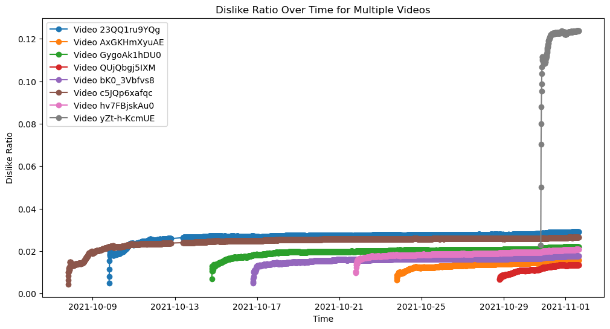

```python
import pandas as pd
import matplotlib.pyplot as plt

video['dislike_ratio'] = video['dislikecnt'] / (video['likecnt'] + video['dislikecnt'])

video_sampled = video['videopk'].unique()[:]

plt.figure(figsize=(12, 6))
for vid in video_sampled:
    sample_df = video[video['videopk'] == vid]
    plt.plot(sample_df['ct'], sample_df['dislike_ratio'], marker='o', label=f'Video {vid}')

plt.xlabel('Time')
plt.ylabel('Dislike Ratio')
plt.title('Dislike Ratio Over Time for Multiple Videos')
plt.legend()
plt.show()
```

## 결론2: 싫어요 비율은 한 번 높아지면 높은 상태로 유지되는 경향이 있는 것으로 보인다(추가 분석 요).